# Toolik_gth89_Sila Flux Cleaning

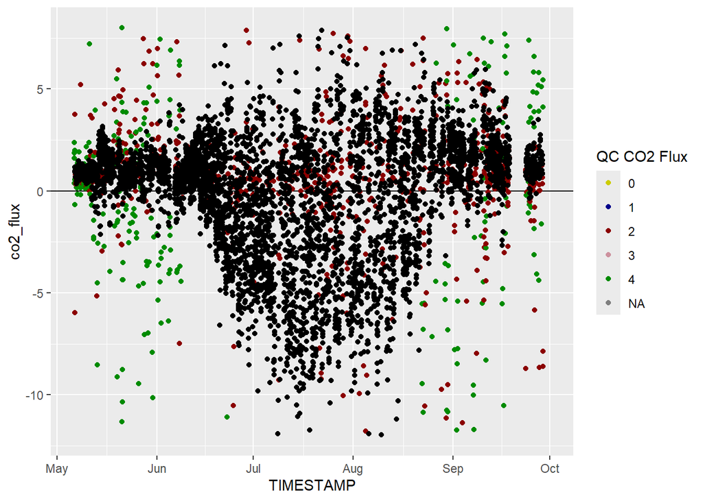

```r
 ggplot(data = df)+geom_hline(yintercept = 0)+
  geom_point(aes(TIMESTAMP,co2_flux,color = co2_flux.flag))+
  geom_point(aes(TIMESTAMP,co2_flux.c),col='black')+
  scale_y_continuous(limits=c(-12,8))+
  scale_x_datetime(limits = as.POSIXct(flux_dates,format="%F"))+
scale_color_manual(values = color_map, name = "QC CO2 Flux")
```

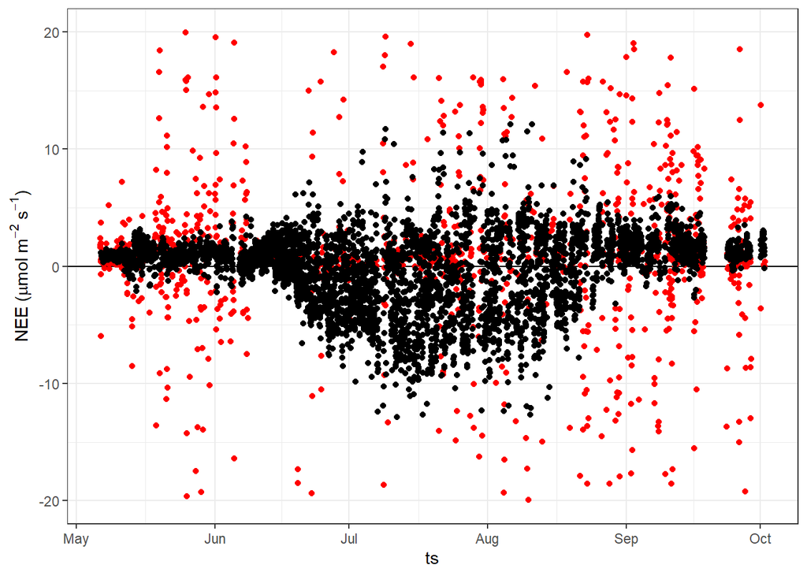

```r
ggplot(data = df)+theme_bw()+geom_hline(yintercept = 0)+
  geom_point(aes(ts,co2_flux), col='red')+
  geom_point(aes(ts,co2_flux.c), col='black')+
  #scale_x_datetime(limits = as.POSIXct(c("2024-07-25",'2024-10-22'),format="%F"))+
  scale_y_continuous (expression('NEE ('*mu*mol~m^-2~s^-1*')'),
                      limits = c(-20,20))
```

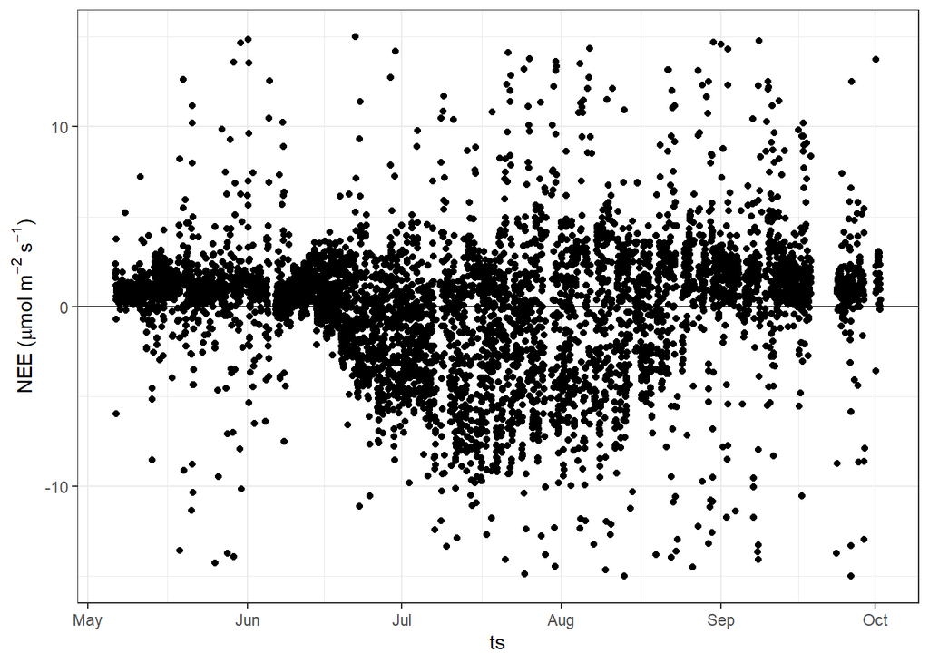

```r
ggplot(data = df)+theme_bw()+geom_hline(yintercept = 0)+
  geom_point(aes(ts,co2_flux))+
  #scale_x_datetime(limits = as.POSIXct(c("2024-07-25",'2024-10-22'),format="%F"))+
  scale_y_continuous (expression('NEE ('*mu*mol~m^-2~s^-1*')'),
                      limits = c(-15,15))
```

See data with multiple layers of the MAD filter to see if it should be changed

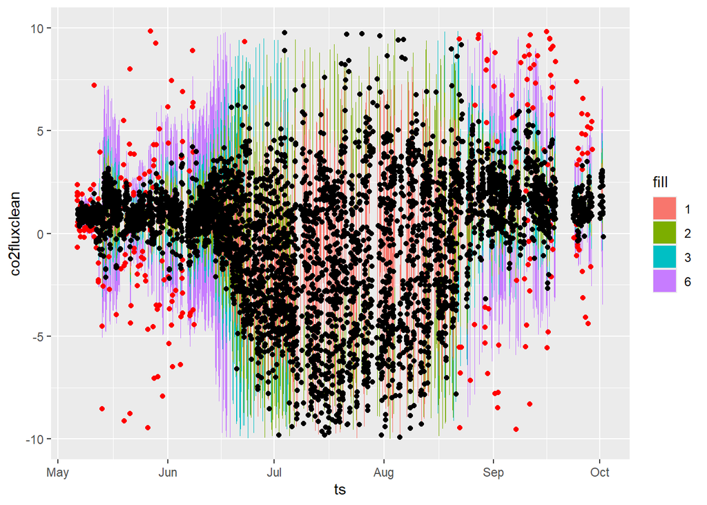

```r
ggplot(data = df)+
  geom_ribbon(aes(x = ts,ymax = Flux_filt+roll.mad*6,ymin = Flux_filt-roll.mad*6,fill='6'))+
  geom_ribbon(aes(x = ts,ymax = Flux_filt+roll.mad*3,ymin = Flux_filt-roll.mad*3,fill='3'))+
  geom_ribbon(aes(x = ts,ymax = Flux_filt+roll.mad*2,ymin = Flux_filt-roll.mad*2,fill='2'))+
  geom_ribbon(aes(x = ts,ymax = Flux_filt+roll.mad*1,ymin = Flux_filt-roll.mad*1,fill='1'))+
  geom_point(aes(ts,co2fluxclean),col='red')+
  geom_point(aes(ts,co2_flux.c),col='black')+
  scale_y_continuous(limits = c(-10,10))
```

## CH4

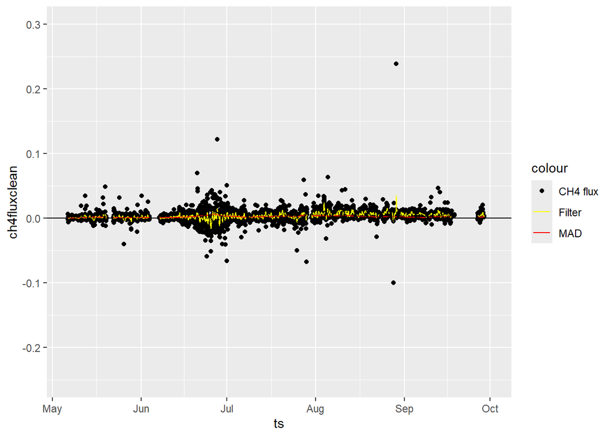

```r
 #apply the moving window filter
f = ch4fluxclean # first make a new flux vector to apply the above filters

# prepare the inputs for a zero-phase (forward and reverse) filter
ind       = which(complete.cases(f))   # first save the index of all the NAs
b         = rep(1,8)/8                 # moving average coefficient
a         = 1                          # coefficient of the ARMA filter
Flux_i    = filtfilt(b, a, na.omit(f)) #create a forward and reverse ARMA filter
Flux_filt = f                          # make a copy of the full fluxes again
Flux_filt[ind] = Flux_i                # apply the filter where the real data exist

n = 7*48 # set the length of the rolling filter, 48 half hours in day * x days
roll.mad = rollapply(data = Flux_filt,
                     width = n,
                     FUN = mad,
                     partial = TRUE,
                     na.rm = T,
                     fill = NA)  #create a rolling MAD or sd or other
roll.mad[is.na(Flux_filt)] = NA  #make NA values where NAs exist in the real data

ggplot(df)+geom_hline(yintercept = 0)+
  geom_point(aes(ts,ch4fluxclean,col='CH4 flux'))+
  geom_line(aes(ts,Flux_filt,col='Filter'))+
  geom_line(aes(ts,roll.mad,col='MAD'))+
  scale_y_continuous(limits = c(-.25,.3))+
  scale_x_datetime(limits = as.POSIXct(flux_dates,format="%F"))+
  scale_color_manual(values=c('black','yellow','red'))
```

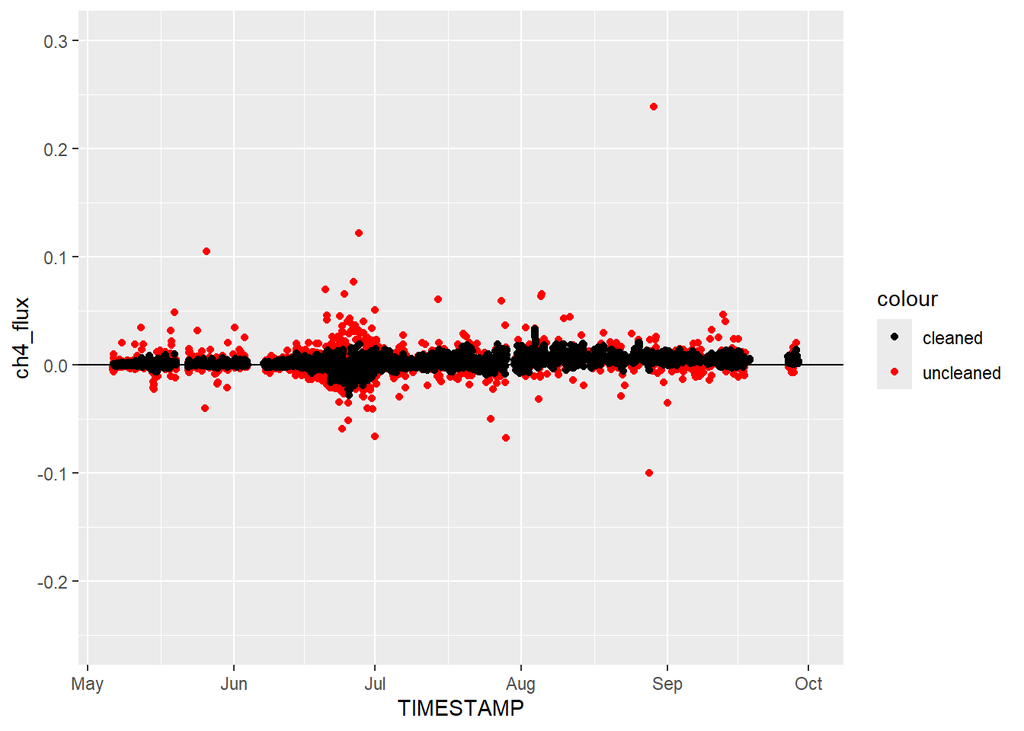

```r
N = 3

df$ch4_flux.c = ifelse(abs(ch4fluxclean - Flux_filt) > (N * roll.mad),NA,ch4fluxclean)

ggplot(data = df)+geom_hline(yintercept = 0)+
  geom_point(aes(TIMESTAMP,ch4_flux,col='uncleaned'))+
  geom_point(aes(TIMESTAMP,ch4_flux.c,col='cleaned'))+
  scale_y_continuous(limits = c(-.25,.3))+
  scale_x_datetime(limits = as.POSIXct(flux_dates,format="%F"))+
  scale_color_manual(values=c('black','red'))
```

Add flag data

```r
df$ch4_flux.flag <- ifelse(is.na(df$ch4_flux.c) & !is.na(ch4fluxclean) & df$ch4_flux.flag != 2 & df$ch4_flux.flag != 3, 4, df$ch4_flux.flag)

df$ch4_flux.flag <- as.factor(df$ch4_flux.flag)
summary(df$ch4_flux.flag)
```

```
##    0    1    2    4 NA's
## 2476 1675  456  567 1959
```

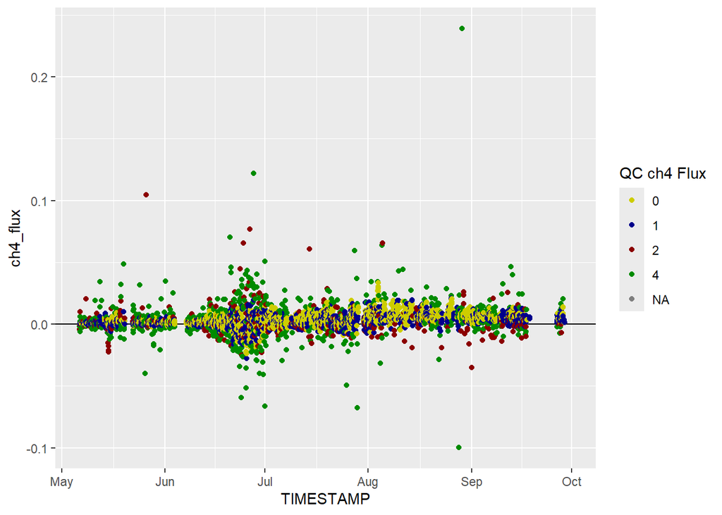

```r
color_map = c("0" = "yellow3", "1" = "darkblue" , "2" =  "red4", "3" = "pink3", "4" = "green4")

ggplot(data = df)+geom_hline(yintercept = 0)+
  geom_point(aes(TIMESTAMP,ch4_flux,color = ch4_flux.flag))+
  #geom_point(aes(TIMESTAMP,ch4_flux.c),col='black')+
  #scale_y_continuous(limits=c(-12,8))+
  scale_x_datetime(limits = as.POSIXct(flux_dates,format="%F"))+
scale_color_manual(values = color_map, name = "QC ch4 Flux")
```

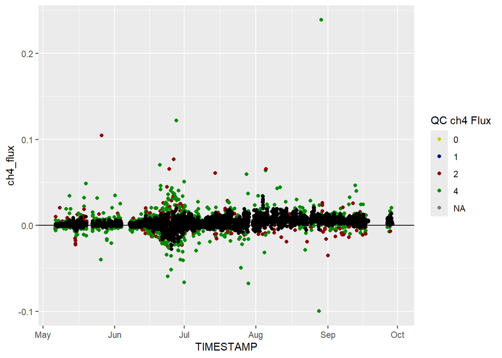

```r
ggplot(data = df)+geom_hline(yintercept = 0)+
  geom_point(aes(TIMESTAMP,ch4_flux,color = ch4_flux.flag))+
  geom_point(aes(TIMESTAMP,ch4_flux.c),col='black')+
  #scale_y_continuous(limits=c(-12,8))+
  scale_x_datetime(limits = as.POSIXct(flux_dates,format="%F"))+
scale_color_manual(values = color_map, name = "QC ch4 Flux")
```

```r
CH4Filter = ggplot(data = df)+geom_hline(yintercept = 0)+
  geom_point(aes(df$ts,ch4fluxclean),col='red')+
  geom_point(aes(df$ts,ch4_flux.c),col='black')+
  scale_y_continuous(limits = c(-.22,.25))

CH4RSSI = ggplot(data = df)+geom_hline(yintercept = 0)+
  geom_line(aes(x=ts,y=rssi_77_mean))+
  scale_y_continuous(limits = c(-1,78))


CH4MOLE = ggplot(data = df)+geom_hline(yintercept = 0)+
  geom_point(aes(x=ts,y=ch4_mole_fraction))+
  scale_y_continuous(limits = c(0,4))

CH4_FALLSOILTCOMP = plot_grid(CH4Filter,CH4RSSI,CH4MOLE,nrow=3,align = 'v')
```

```
## Error in `geom_line()`:
## ! Problem while computing aesthetics.
## ℹ Error occurred in the 2nd layer.
## Caused by error:
## ! object 'rssi_77_mean' not found
```

```r
CH4_FALLSOILTCOMP
```

```
## Error: object 'CH4_FALLSOILTCOMP' not found
```

#Compare cleaned vs. uncleaned

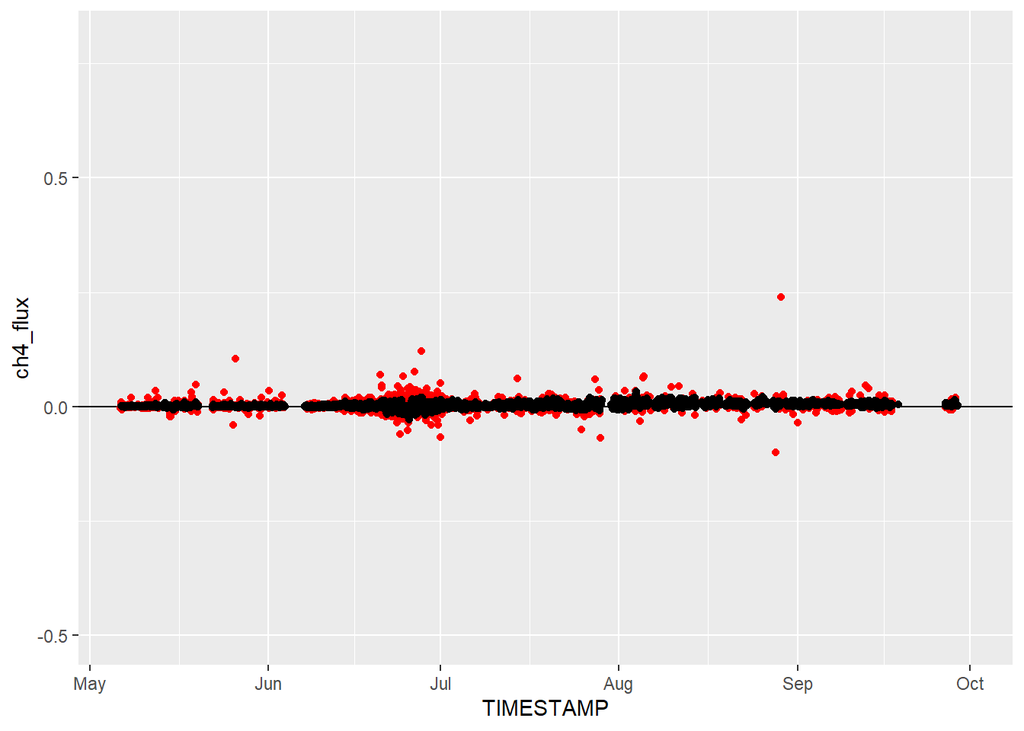

```r
ggplot(data = df)+geom_hline(yintercept = 0)+
  geom_point(aes(TIMESTAMP,ch4_flux),col='red')+
  geom_point(aes(TIMESTAMP,ch4_flux.c),col='black')+
  scale_y_continuous(limits=c(-.5,.8))+
    #scale_x_datetime(limits = as.POSIXct(c('2024-09-01','2024-09-12'),format="%F"))
 scale_x_datetime(limits = as.POSIXct(flux_dates,format="%F"))
```

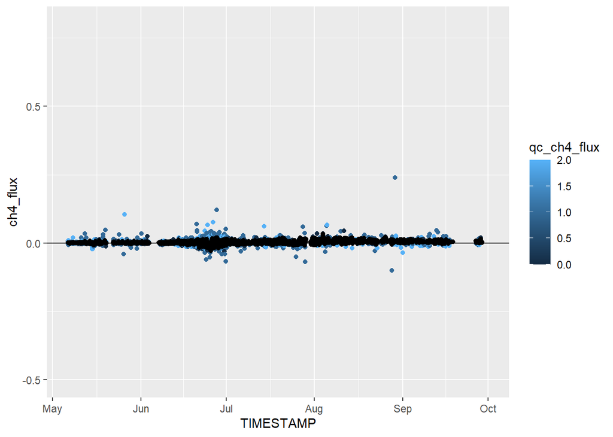

```r
ggplot(data = df)+geom_hline(yintercept = 0)+
  geom_point(aes(TIMESTAMP,ch4_flux,colour = qc_ch4_flux))+
  geom_point(aes(TIMESTAMP,ch4_flux.c),col='black')+
  scale_y_continuous(limits=c(-.5,.8))+
    #scale_x_datetime(limits = as.POSIXct(c('2024-09-01','2024-09-12'),format="%F"))
 scale_x_datetime(limits = as.POSIXct(flux_dates,format="%F"))
```

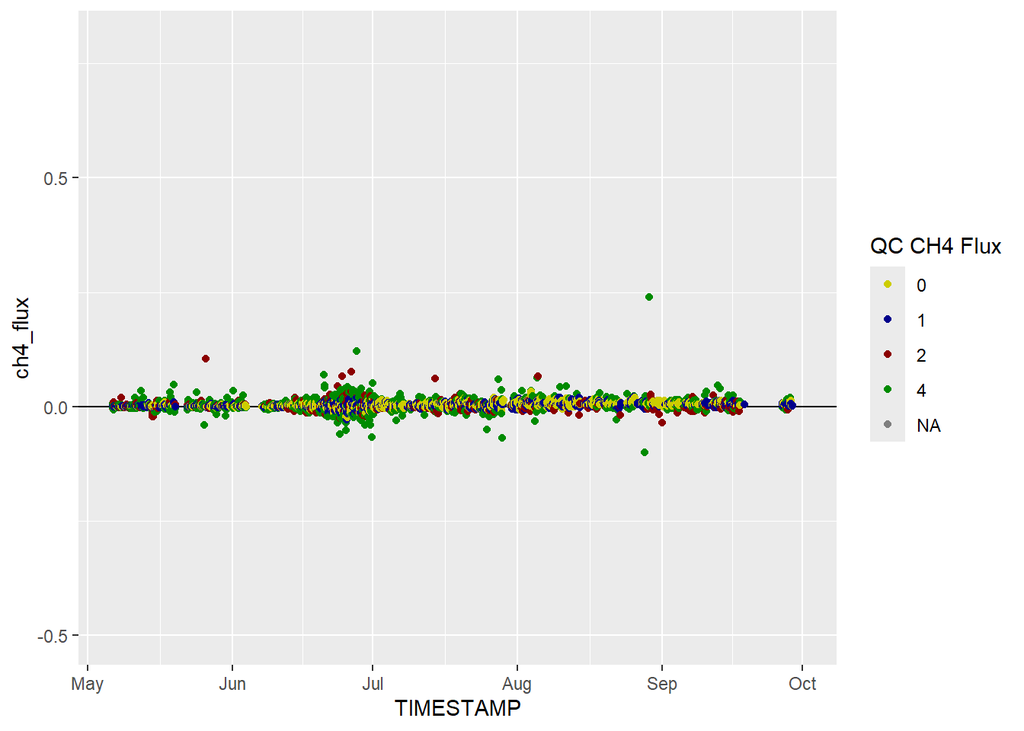

```r
ggplot(data = df)+geom_hline(yintercept = 0)+
  geom_point(aes(TIMESTAMP,ch4_flux,color = ch4_flux.flag))+
  scale_y_continuous(limits=c(-.5,.8))+
  scale_x_datetime(limits = as.POSIXct(flux_dates,format="%F"))+
scale_color_manual(values = color_map, name = "QC CH4 Flux")
```

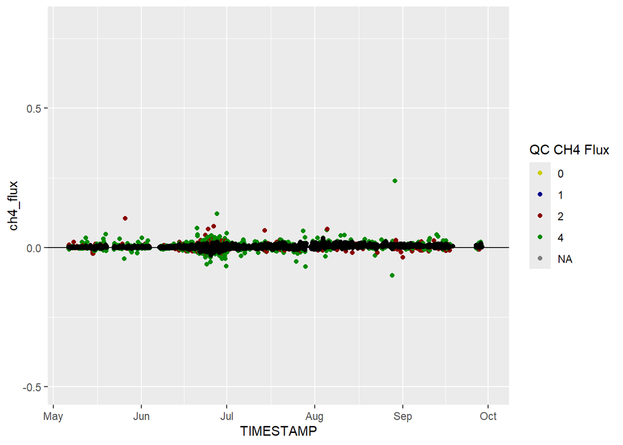

```r
 ggplot(data = df)+geom_hline(yintercept = 0)+
  geom_point(aes(TIMESTAMP,ch4_flux,color = ch4_flux.flag))+
  geom_point(aes(TIMESTAMP,ch4_flux.c),col='black')+
  scale_y_continuous(limits=c(-.5,.8))+
  scale_x_datetime(limits = as.POSIXct(flux_dates,format="%F"))+
scale_color_manual(values = color_map, name = "QC CH4 Flux")
```

## H

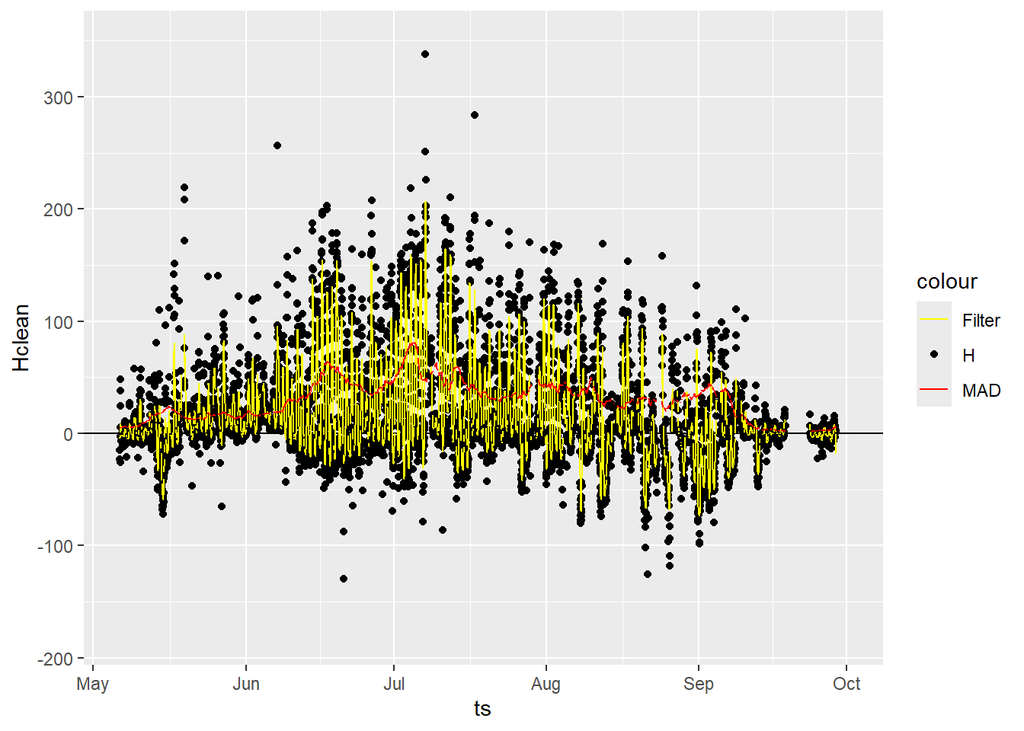

```r
# apply the moving window filter
f = Hclean # first make a new flux vector to apply the above filters

# prepare the inputs for a zero-phase (forward and reverse) filter
ind       = which(complete.cases(f))   # first save the index of all the NAs
b         = rep(1,8)/8                 # moving average coefficient
a         = 1                          # coefficient of the ARMA filter
Flux_i    = filtfilt(b, a, na.omit(f)) #create a forward and reverse ARMA filter
Flux_filt = f                          # make a copy of the full fluxes again
Flux_filt[ind] = Flux_i                # apply the filter where the real data exist

n = 7*48 # set the length of the rolling filter, 48 half hours in day * x days
roll.mad = rollapply(data = Flux_filt,
                     width = n,
                     FUN = mad,
                     partial = TRUE,
                     na.rm = T,
                     fill = NA)  #create a rolling MAD or sd or other
roll.mad[is.na(Flux_filt)] = NA  #make NA values where NAs exist in the real data

ggplot(df)+geom_hline(yintercept = 0)+
  geom_point(aes(ts,Hclean,col='H'))+
  geom_line(aes(ts,Flux_filt,col='Filter'))+
  geom_line(aes(ts,roll.mad,col='MAD'))+
  scale_y_continuous(limits = c(-180,350))+
  scale_x_datetime(limits = as.POSIXct(flux_dates,format="%F"))+
  scale_color_manual(values=c('yellow','black','red'))
```

Now filter the data based on this signal (N) adjust this to tweak how many MADs to be away from the norm, add clean value to dataframe (_.c) and Compare Clean vs. Uncleaned

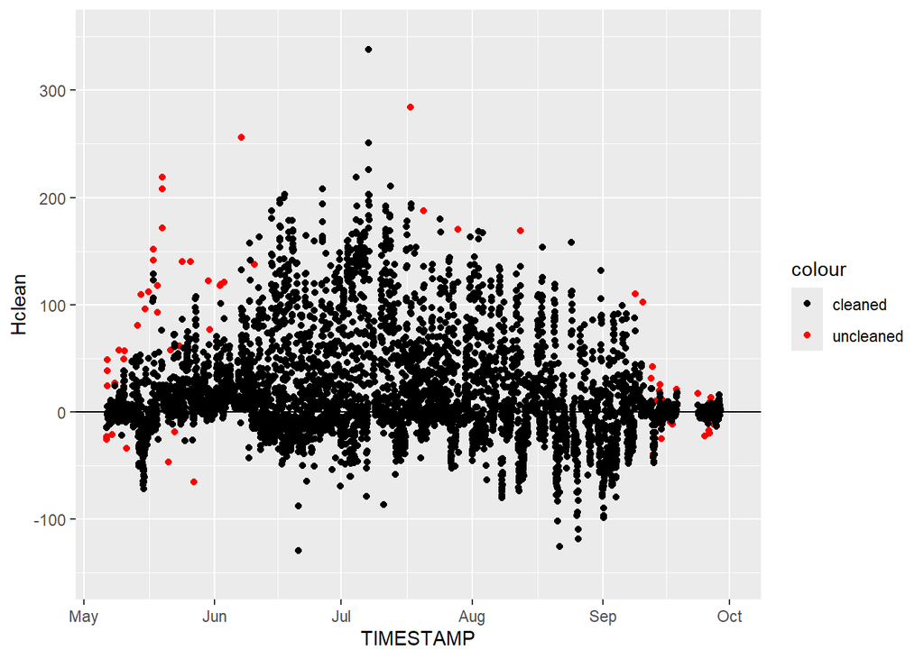

```r
N = 3

df$H.c = ifelse(abs(Hclean - Flux_filt) > (N * roll.mad),NA,Hclean)

ggplot(data = df)+geom_hline(yintercept = 0)+
  geom_point(aes(TIMESTAMP,Hclean,col='uncleaned'))+
  geom_point(aes(TIMESTAMP,H.c,col='cleaned'))+
  scale_y_continuous(limits=c(-150,350))+
  scale_x_datetime(limits = as.POSIXct(flux_dates,format="%F"))+
  scale_color_manual(values=c('black','red'))
```

See data with multiple layers of the MAD filter to see if it should be changed

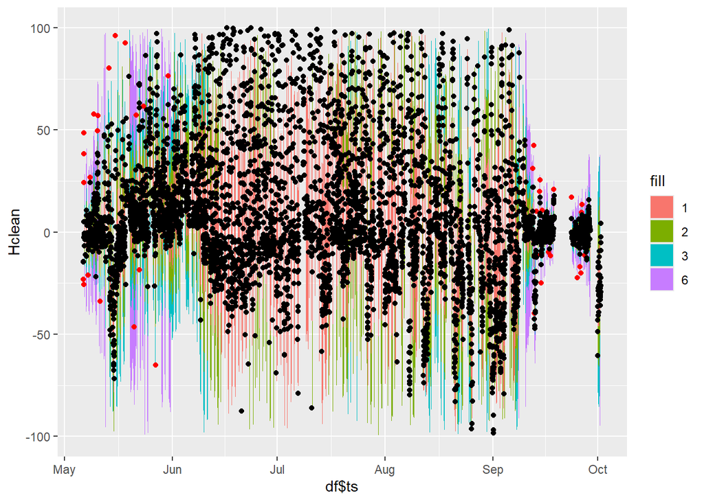

```r
ggplot(data = df)+
  geom_ribbon(aes(x = df$ts,ymax = Flux_filt+roll.mad*6,ymin = Flux_filt-roll.mad*6,fill='6'))+
  geom_ribbon(aes(x = df$ts,ymax = Flux_filt+roll.mad*3,ymin = Flux_filt-roll.mad*3,fill='3'))+
  geom_ribbon(aes(x = df$ts,ymax = Flux_filt+roll.mad*2,ymin = Flux_filt-roll.mad*2,fill='2'))+
  geom_ribbon(aes(x = df$ts,ymax = Flux_filt+roll.mad*1,ymin = Flux_filt-roll.mad*1,fill='1'))+
  geom_point(aes(df$ts,Hclean),col='red')+
  geom_point(aes(df$ts,H.c),col='black')+
  scale_y_continuous(limits = c(-100,100))
```

Add flag data

```r
df$H.flag <- ifelse(is.na(df$H.c) & !is.na(Hclean) & df$H.flag != 2 & df$H.flag != 3, 4, df$H.flag)

df$H.flag <- as.factor(df$H.flag)
summary(df$H.flag)
```

```
##    0    1    2    3    4 NA's
## 3395 2051  642    4   65  976
```

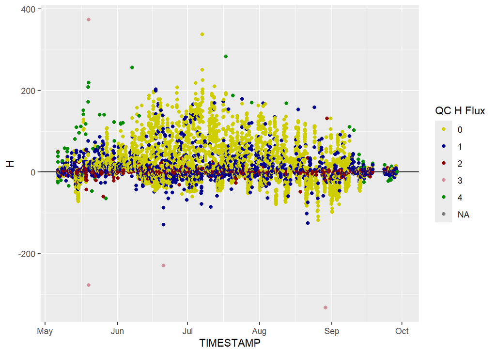

```r
color_map = c("0" = "yellow3", "1" = "darkblue" , "2" =  "red4", "3" = "pink3", "4" = "green4")

ggplot(data = df)+geom_hline(yintercept = 0)+
  geom_point(aes(TIMESTAMP,H,color = H.flag))+
  #geom_point(aes(TIMESTAMP,H.c),col='black')+
  #scale_y_continuous(limits=c(-12,8))+
  scale_x_datetime(limits = as.POSIXct(flux_dates,format="%F"))+
scale_color_manual(values = color_map, name = "QC H Flux")
```

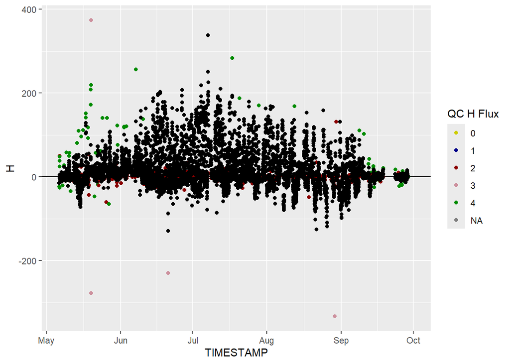

```r
ggplot(data = df)+geom_hline(yintercept = 0)+
  geom_point(aes(TIMESTAMP,H,color = H.flag))+
  geom_point(aes(TIMESTAMP,H.c),col='black')+
  #scale_y_continuous(limits=c(-12,8))+
  scale_x_datetime(limits = as.POSIXct(flux_dates,format="%F"))+
scale_color_manual(values = color_map, name = "QC H Flux")
```

## LE

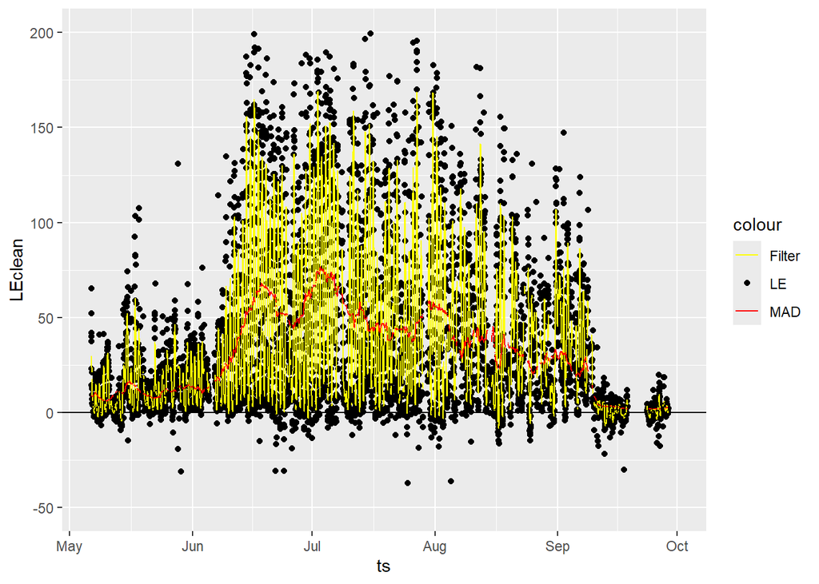

```r
# apply the moving window filter
f = LEclean # first make a new flux vector to apply the above filters

# prepare the inputs for a zero-phase (forward and reverse) filter
ind       = which(complete.cases(f))   # first save the index of all the NAs
b         = rep(1,8)/8                 # moving average coefficient
a         = 1                          # coefficient of the ARMA filter
Flux_i    = filtfilt(b, a, na.omit(f)) #create a forward and reverse ARMA filter
Flux_filt = f                          # make a copy of the full fluxes again
Flux_filt[ind] = Flux_i                # apply the filter where the real data exist

n = 7*48 # set the length of the rolling filter, 48 half hours in day * x days
roll.mad = rollapply(data = Flux_filt,
                     width = n,
                     FUN = mad,
                     partial = TRUE,
                     na.rm = T,
                     fill = NA)  #create a rolling MAD or sd or other
roll.mad[is.na(Flux_filt)] = NA  #make NA values where NAs exist in the real data

ggplot(df)+geom_hline(yintercept = 0)+
  geom_point(aes(ts,LEclean,col='LE'))+
  geom_line(aes(ts,Flux_filt,col='Filter'))+
  geom_line(aes(ts,roll.mad,col='MAD'))+
  scale_y_continuous(limits = c(-50,200))+
  scale_x_datetime(limits = as.POSIXct(flux_dates,format="%F"))+
  scale_color_manual(values=c('yellow','black','red'))
```

Now filter the data based on this signal (N) adjust this to tweak how many MADs to be away from the norm

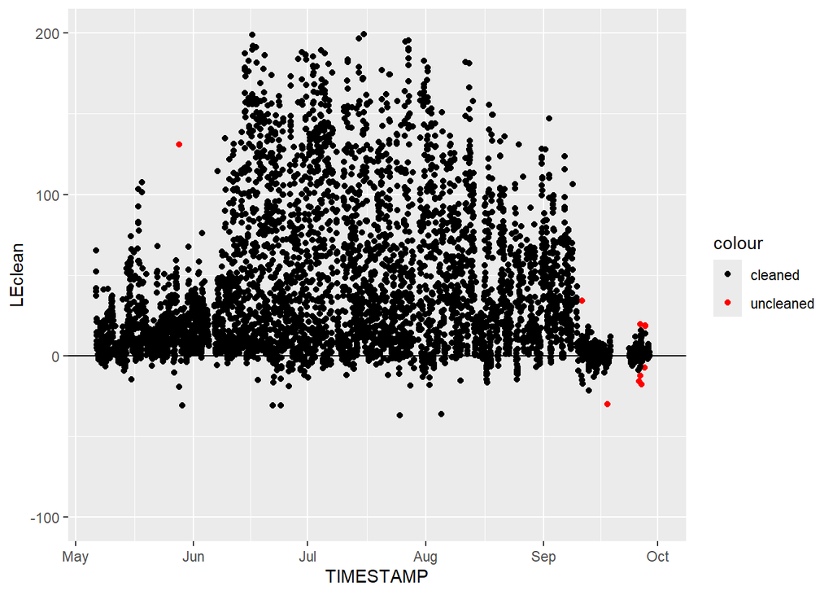

```r
N = 6

df$LE.c = ifelse(abs(LEclean - Flux_filt) > (N * roll.mad),NA,LEclean)

ggplot(data = df)+geom_hline(yintercept = 0)+
  geom_point(aes(TIMESTAMP,LEclean,col='uncleaned'))+
  geom_point(aes(TIMESTAMP,LE.c,col='cleaned'))+
  scale_y_continuous(limits=c(-100,200))+
  scale_x_datetime(limits = as.POSIXct(flux_dates,format="%F"))+
  scale_color_manual(values=c('black','red'))
```

See data with multiple layers of the MAD filter to see if it should be changed

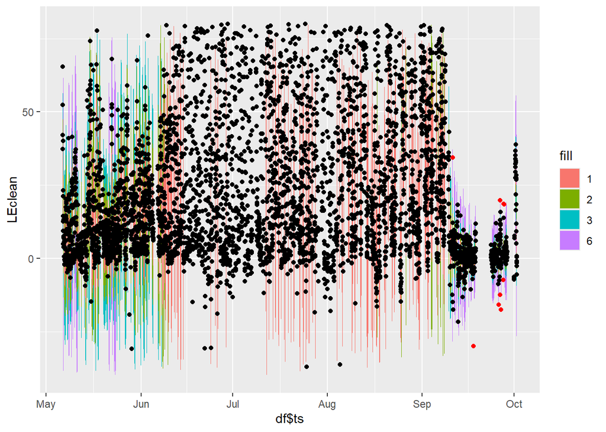

```r
ggplot(data = df)+
  geom_ribbon(aes(x = df$ts,ymax = Flux_filt+roll.mad*6,ymin = Flux_filt-roll.mad*6,fill='6'))+
  geom_ribbon(aes(x = df$ts,ymax = Flux_filt+roll.mad*3,ymin = Flux_filt-roll.mad*3,fill='3'))+
  geom_ribbon(aes(x = df$ts,ymax = Flux_filt+roll.mad*2,ymin = Flux_filt-roll.mad*2,fill='2'))+
  geom_ribbon(aes(x = df$ts,ymax = Flux_filt+roll.mad*1,ymin = Flux_filt-roll.mad*1,fill='1'))+
  geom_point(aes(df$ts,LEclean),col='red')+
  geom_point(aes(df$ts,LE.c),col='black')+
  scale_y_continuous(limits = c(-40,80))
```

Add flag data

```r
df$LE.flag <- ifelse(is.na(df$LE.c) & !is.na(co2fluxclean) & df$LE.flag != 2 & df$LE.flag != 3, 4, df$LE.flag)

df$LE.flag <- as.factor(df$LE.flag)
summary(df$LE.flag)
```

```
##    0    1    2    3    4 NA's
## 3287 2094  593   10    2 1147
```

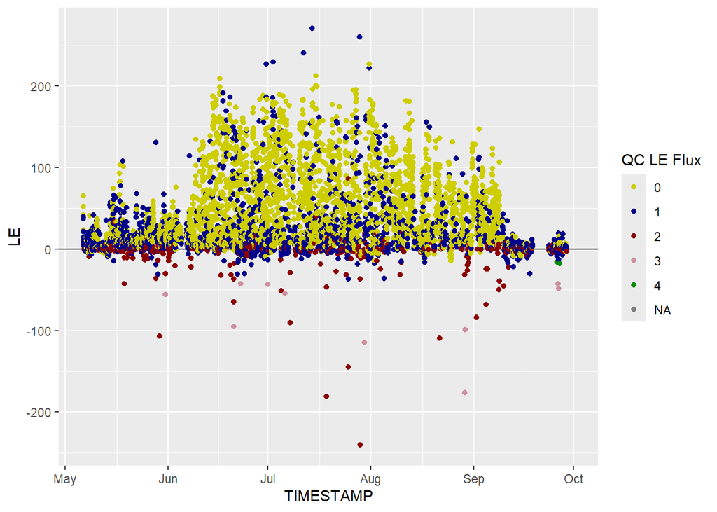

```r
color_map = c("0" = "yellow3", "1" = "darkblue" , "2" =  "red4", "3" = "pink3", "4" = "green4")

ggplot(data = df)+geom_hline(yintercept = 0)+
  geom_point(aes(TIMESTAMP,LE,color = LE.flag))+
  #geom_point(aes(TIMESTAMP,LE.c),col='black')+
  #scale_y_continuous(limits=c(-12,8))+
  scale_x_datetime(limits = as.POSIXct(flux_dates,format="%F"))+
scale_color_manual(values = color_map, name = "QC LE Flux")
```

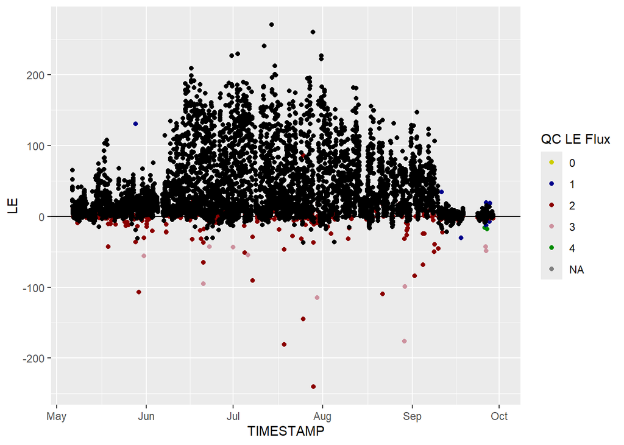

```r
ggplot(data = df)+geom_hline(yintercept = 0)+
  geom_point(aes(TIMESTAMP,LE,color = LE.flag))+
  geom_point(aes(TIMESTAMP,LE.c),col='black')+
  #scale_y_continuous(limits=c(-12,8))+
  scale_x_datetime(limits = as.POSIXct(flux_dates,format="%F"))+
scale_color_manual(values = color_map, name = "QC LE Flux")
```

# Main Plots

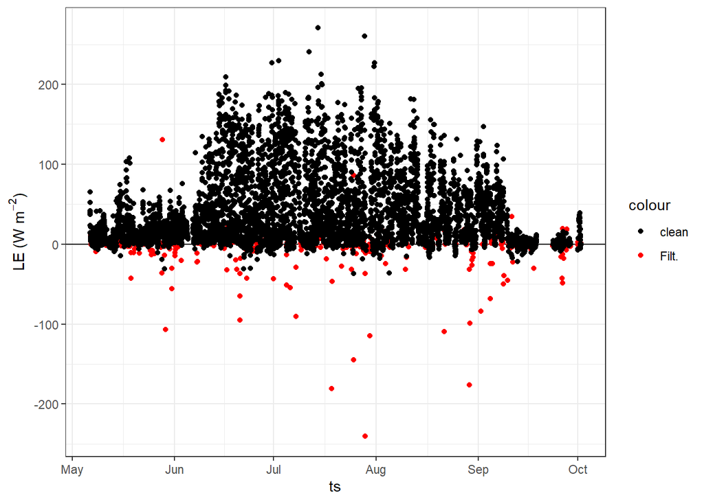

```r
ggplot(data = df)+theme_bw()+geom_hline(yintercept = 0)+
  geom_point(aes(ts,LE,col='Filt.'))+
  geom_point(aes(ts,LE.c,col='clean'))+
  scale_y_continuous(expression('LE ('*W~m^-2*')'))+
  scale_color_manual(values = c('black','red'))
```

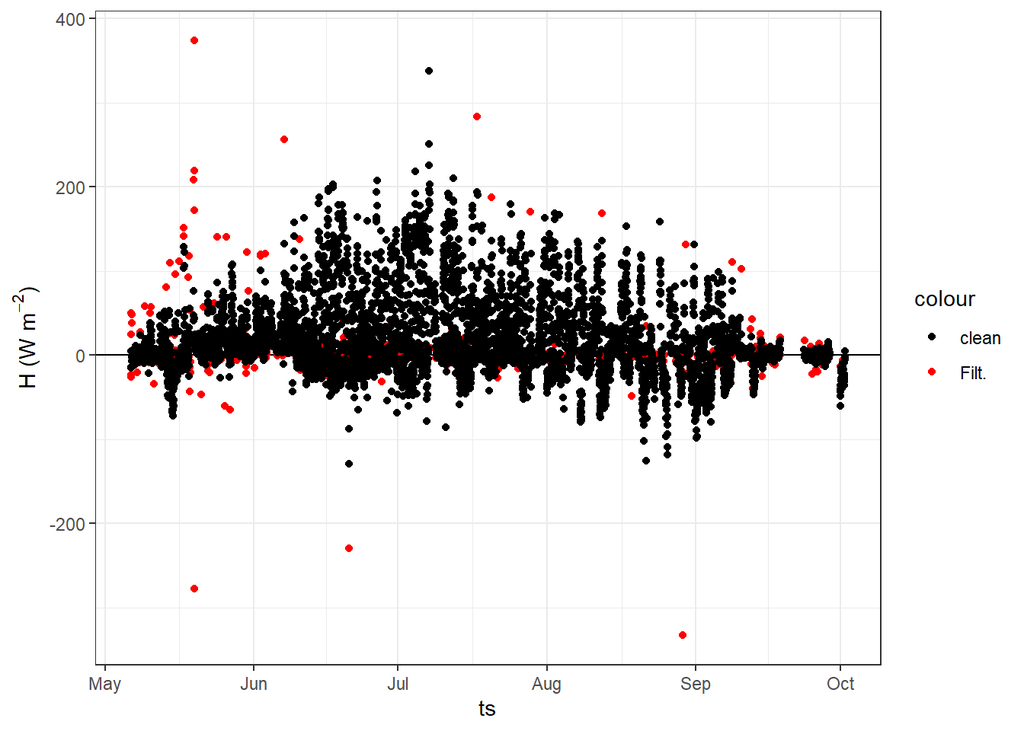

```r
ggplot(data = df)+theme_bw()+geom_hline(yintercept = 0)+
  geom_point(aes(ts,H,col='Filt.'))+
  geom_point(aes(ts,H.c,col='clean'))+
  scale_y_continuous(expression('H ('*W~m^-2*')'))+
  scale_color_manual(values = c('black','red'))
```

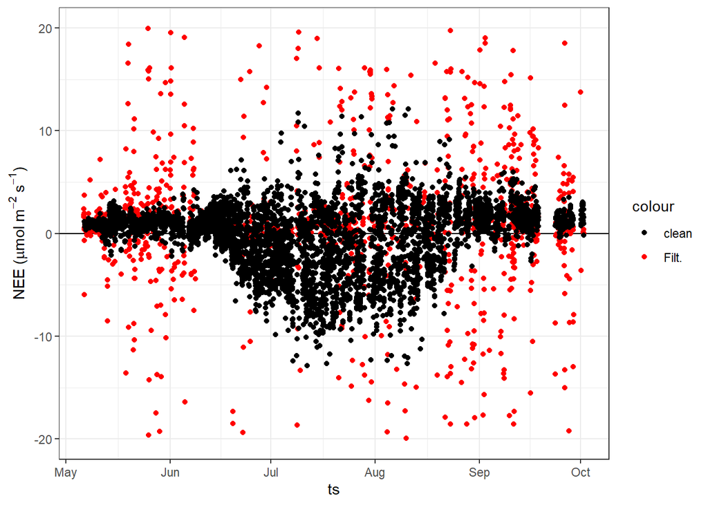

```r
ggplot(data = df)+theme_bw()+geom_hline(yintercept = 0)+
  geom_point(aes(ts,co2_flux,col='Filt.'))+
  geom_point(aes(ts,co2_flux.c,col='clean'))+
  scale_y_continuous (expression('NEE ('*mu*mol~m^-2~s^-1*')'),
                      limits = c(-20,20))+
  scale_color_manual(values = c('black','red'))
```

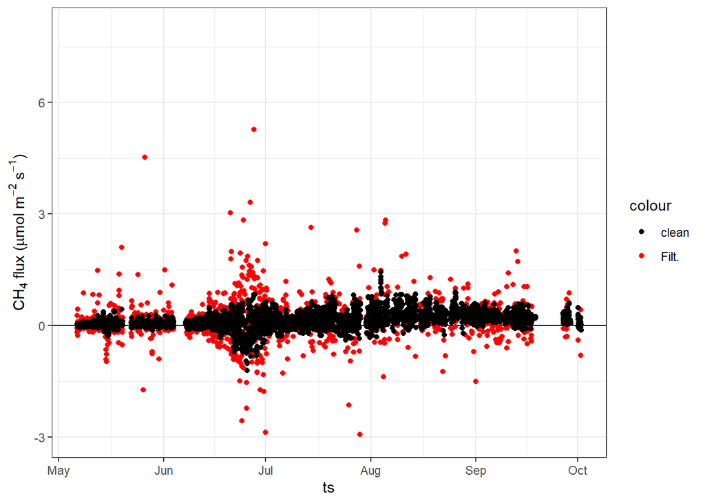

```r
ggplot(data = df)+theme_bw()+geom_hline(yintercept = 0)+
  geom_point(aes(ts,ch4_flux*43.2,col='Filt.'))+
  geom_point(aes(ts,ch4_flux.c*43.2,col='clean'))+
  scale_y_continuous(expression(CH[4]~'flux ('*mu*mol~m^-2~s^-1*')'),
                     limits = c(-3,8))+
  scale_color_manual(values = c('black','red'))
```

# Diurnal Fluxes

set hour and month vectors to be able to take the averages

```r
df$hour = as.numeric(format(df$ts,'%H'))
df$month = as.numeric(format(df$ts,'%m'))

diel = df %>%
  group_by(hour,month) %>%
  select(co2_flux.c,ch4_flux.c,LE.c,H.c,hour,month) %>%
  summarise_all(.funs = c(median,sd),na.rm=T)
#
diel = subset(diel,!is.na(diel$month))
```

## NEE

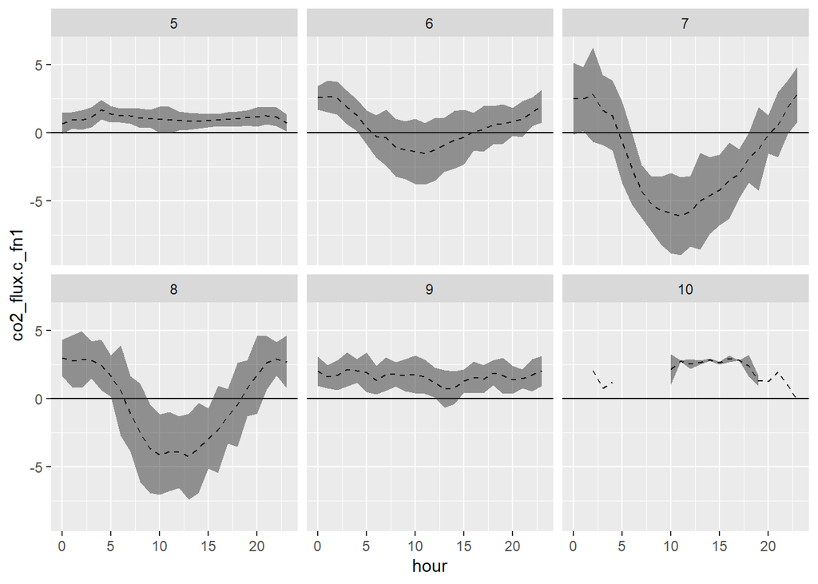

```r
ggplot(data = diel)+geom_hline(yintercept = 0)+
  geom_line(aes(hour,co2_flux.c_fn1),lty=2)+
  geom_ribbon(aes(x = hour,y = co2_flux.c_fn1,
                  ymax = co2_flux.c_fn1 + co2_flux.c_fn2,
                  ymin = co2_flux.c_fn1 - co2_flux.c_fn2),
              alpha= 0.5)+
  facet_wrap(~month)
```

```r
levels(diel$month)
```

[output not shown]

## CH4

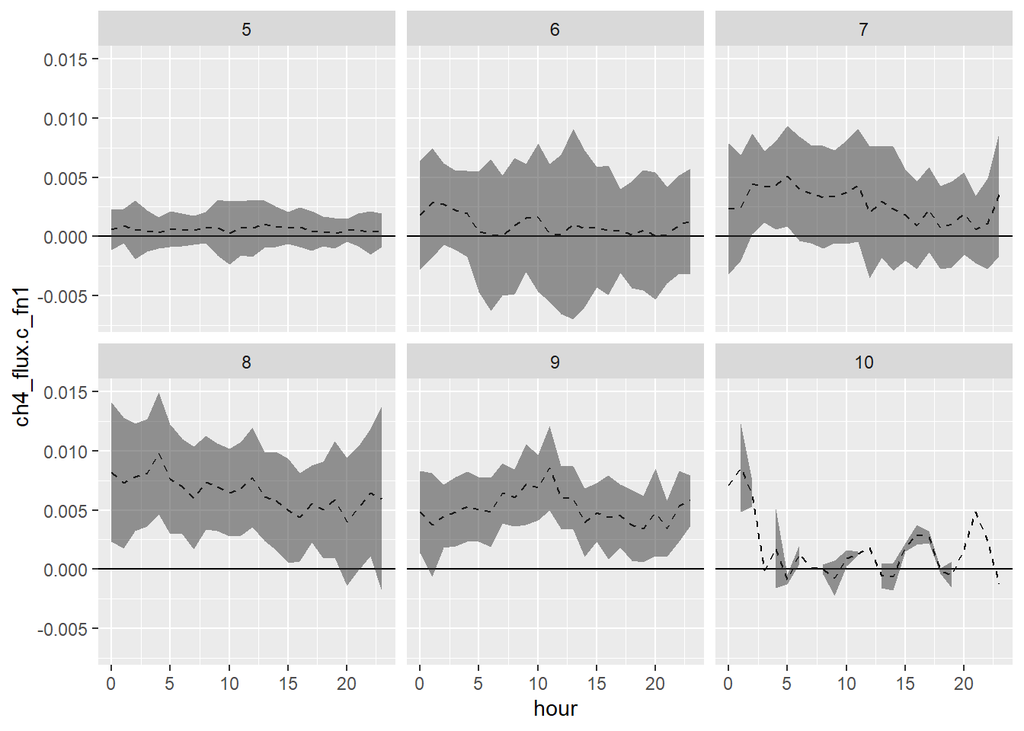

```r
ggplot(data = diel)+geom_hline(yintercept = 0)+
  geom_line(aes(hour,ch4_flux.c_fn1),lty=2)+
  geom_ribbon(aes(x = hour,y = ch4_flux.c_fn1,
                  ymax = ch4_flux.c_fn1 + ch4_flux.c_fn2,
                  ymin = ch4_flux.c_fn1 - ch4_flux.c_fn2),
              alpha= 0.5)+
  facet_wrap(~month)
```

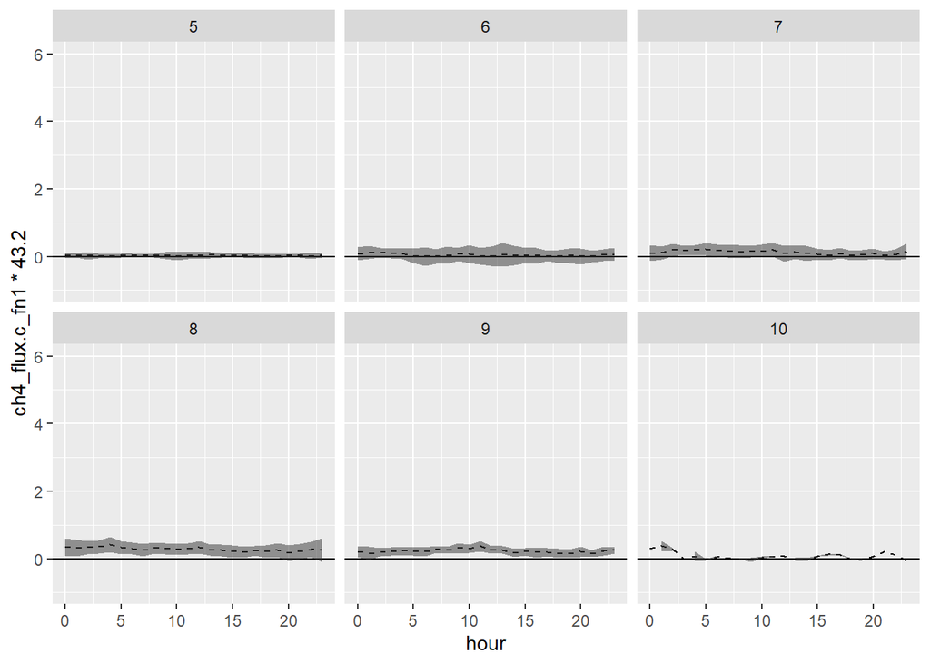

```r
ggplot(data = diel)+geom_hline(yintercept = 0)+
  geom_line(aes(hour,ch4_flux.c_fn1*43.2),lty=2)+
  geom_ribbon(aes(x = hour,y = ch4_flux.c_fn1*43.2,
                  ymax = ch4_flux.c_fn1*43.2 + ch4_flux.c_fn2*43.2,
                  ymin = ch4_flux.c_fn1*43.2 - ch4_flux.c_fn2*43.2),
              alpha= 0.5)+
  scale_y_continuous(limits = c(-1,6))+
  facet_wrap(~month)
```

## H

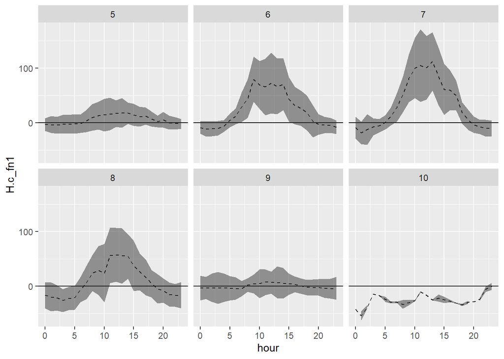

```r
ggplot(data = diel)+geom_hline(yintercept = 0)+
  geom_line(aes(hour,H.c_fn1),lty=2)+
  geom_ribbon(aes(x = hour,y = H.c_fn1,
                  ymax = H.c_fn1 + H.c_fn2,
                  ymin = H.c_fn1 - H.c_fn2),
              alpha= 0.5)+
  facet_wrap(~month)
```

## LE

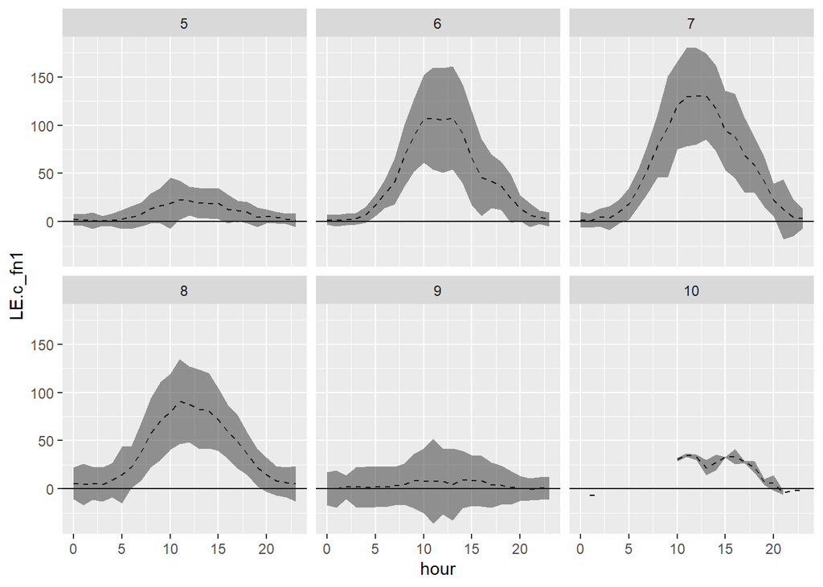

```r
ggplot(data = diel)+geom_hline(yintercept = 0)+
  geom_line(aes(hour,LE.c_fn1),lty=2)+
  geom_ribbon(aes(x = hour,y = LE.c_fn1,
                  ymax = LE.c_fn1 + LE.c_fn2,
                  ymin = LE.c_fn1 - LE.c_fn2),
              alpha= 0.5)+
  facet_wrap(~month)
```

# Save

```r
df <- df[!duplicated(df$TIMESTAMP), ]

write.csv(x = df,file = 'C:/Users/klynoe/Documents/toolik/R_outputs/toolik_Flux_Met_Clean_sep_25.csv',row.names = F,quote = F)
```

#NEST AND SPLIT THE DATA BY MONTH AND SAVE IN DESIRED DIRECTORY

```r
base_path = "C:/Users/klynoe/Documents/toolik/R_outputs/met_and_flux/"

# Nest the data and prepare for saving
data_nested = df %>%
  mutate(TIMESTAMP = as.POSIXct(TIMESTAMP, format = "%Y-%m-%d %H:%M:%S")) %>%
  mutate(year_month = format(TIMESTAMP, "%Y%m")) %>%
  group_by(year_month) %>%
  nest() %>%
  ungroup() %>%  # Important to prevent errors with grouped data
  mutate(file_path = paste0(base_path, year_month, ".csv"))

# Write each nested data frame to the specified file path
walk2(
  .x = data_nested$data,
  .y = data_nested$file_path,
  ~ {
    # Ensure the nested data frame has columns as character if needed
    .x[] <- lapply(.x, as.character)  # Convert all columns to character, if needed

    # Write to CSV without adding the units row
    write.csv(.x, .y, row.names = FALSE)
  }
)
```

```
## Error in `map2()`:
## ℹ In index: 1.
## Caused by error in `file()`:
## ! cannot open the connection
```